# Risk Factor Analysis

## Outcome Variable

**Outcome Variable:** wast_rec90d

## Predictor Variables

**Intervention Variable:** mwtkg

**Adjustment Set:**

- arm
- W_mage
- meducyrs
- feducyrs
- W_nchldlt5
- brthmon
- W_parity
- delta_W_mage
- delta_meducyrs
- delta_feducyrs
- delta_W_nchldlt5
- delta_brthmon
- delta_W_parity

## Stratifying Variables

The analysis was stratified on these variable(s):

- agecat
- studyid
- country

## Data Summary

| agecat | studyid | country | mwtkg | wast_rec90d | n_cell | n |
| --- | --- | --- | --- | --- | --- | --- |
| 0-24 months | iLiNS-Zinc | BURKINA FASO | >=58 kg | 0 | 173 | 794 |
| 0-24 months | iLiNS-Zinc | BURKINA FASO | >=58 kg | 1 | 9 | 794 |
| 0-24 months | iLiNS-Zinc | BURKINA FASO | <52 kg | 0 | 344 | 794 |
| 0-24 months | iLiNS-Zinc | BURKINA FASO | <52 kg | 1 | 18 | 794 |
| 0-24 months | iLiNS-Zinc | BURKINA FASO | [52-58) kg | 0 | 242 | 794 |
| 0-24 months | iLiNS-Zinc | BURKINA FASO | [52-58) kg | 1 | 8 | 794 |
| 0-24 months | JiVitA-3 | BANGLADESH | >=58 kg | 0 | 93 | 7562 |
| 0-24 months | JiVitA-3 | BANGLADESH | >=58 kg | 1 | 76 | 7562 |
| 0-24 months | JiVitA-3 | BANGLADESH | <52 kg | 0 | 4003 | 7562 |
| 0-24 months | JiVitA-3 | BANGLADESH | <52 kg | 1 | 2902 | 7562 |
| 0-24 months | JiVitA-3 | BANGLADESH | [52-58) kg | 0 | 272 | 7562 |
| 0-24 months | JiVitA-3 | BANGLADESH | [52-58) kg | 1 | 216 | 7562 |
| 0-24 months | LCNI-5 | MALAWI | >=58 kg | 0 | 5 | 78 |
| 0-24 months | LCNI-5 | MALAWI | >=58 kg | 1 | 1 | 78 |
| 0-24 months | LCNI-5 | MALAWI | <52 kg | 0 | 47 | 78 |
| 0-24 months | LCNI-5 | MALAWI | <52 kg | 1 | 10 | 78 |
| 0-24 months | LCNI-5 | MALAWI | [52-58) kg | 0 | 13 | 78 |
| 0-24 months | LCNI-5 | MALAWI | [52-58) kg | 1 | 2 | 78 |
| 0-24 months | MAL-ED | BANGLADESH | >=58 kg | 0 | 3 | 122 |
| 0-24 months | MAL-ED | BANGLADESH | >=58 kg | 1 | 9 | 122 |
| 0-24 months | MAL-ED | BANGLADESH | <52 kg | 0 | 35 | 122 |
| 0-24 months | MAL-ED | BANGLADESH | <52 kg | 1 | 59 | 122 |
| 0-24 months | MAL-ED | BANGLADESH | [52-58) kg | 0 | 5 | 122 |
| 0-24 months | MAL-ED | BANGLADESH | [52-58) kg | 1 | 11 | 122 |
| 0-24 months | MAL-ED | BRAZIL | >=58 kg | 0 | 4 | 23 |
| 0-24 months | MAL-ED | BRAZIL | >=58 kg | 1 | 8 | 23 |
| 0-24 months | MAL-ED | BRAZIL | <52 kg | 0 | 0 | 23 |
| 0-24 months | MAL-ED | BRAZIL | <52 kg | 1 | 2 | 23 |
| 0-24 months | MAL-ED | BRAZIL | [52-58) kg | 0 | 2 | 23 |
| 0-24 months | MAL-ED | BRAZIL | [52-58) kg | 1 | 7 | 23 |

[output cut: 270 more lines]

The following strata were considered:

- agecat: 0-24 months, studyid: iLiNS-Zinc, country: BURKINA FASO
- agecat: 0-24 months, studyid: JiVitA-3, country: BANGLADESH
- agecat: 0-24 months, studyid: LCNI-5, country: MALAWI
- agecat: 0-24 months, studyid: MAL-ED, country: BANGLADESH
- agecat: 0-24 months, studyid: MAL-ED, country: BRAZIL
- agecat: 0-24 months, studyid: MAL-ED, country: INDIA
- agecat: 0-24 months, studyid: MAL-ED, country: NEPAL
- agecat: 0-24 months, studyid: MAL-ED, country: PERU
- agecat: 0-24 months, studyid: MAL-ED, country: SOUTH AFRICA
- agecat: 0-24 months, studyid: MAL-ED, country: TANZANIA, UNITED REPUBLIC OF
- agecat: 0-24 months, studyid: NIH-Birth, country: BANGLADESH
- agecat: 0-24 months, studyid: NIH-Crypto, country: BANGLADESH
- agecat: 0-24 months, studyid: PROBIT, country: BELARUS
- agecat: 0-24 months, studyid: PROVIDE, country: BANGLADESH
- agecat: 0-24 months, studyid: SAS-CompFeed, country: INDIA
- agecat: 0-24 months, studyid: TanzaniaChild2, country: TANZANIA, UNITED REPUBLIC OF
- agecat: 0-24 months, studyid: ZVITAMBO, country: ZIMBABWE
- agecat: 0-6 months, studyid: JiVitA-3, country: BANGLADESH
- agecat: 0-6 months, studyid: LCNI-5, country: MALAWI
- agecat: 0-6 months, studyid: MAL-ED, country: BANGLADESH
- agecat: 0-6 months, studyid: MAL-ED, country: BRAZIL
- agecat: 0-6 months, studyid: MAL-ED, country: INDIA
- agecat: 0-6 months, studyid: MAL-ED, country: NEPAL
- agecat: 0-6 months, studyid: MAL-ED, country: PERU
- agecat: 0-6 months, studyid: MAL-ED, country: SOUTH AFRICA
- agecat: 0-6 months, studyid: MAL-ED, country: TANZANIA, UNITED REPUBLIC OF
- agecat: 0-6 months, studyid: NIH-Birth, country: BANGLADESH
- agecat: 0-6 months, studyid: NIH-Crypto, country: BANGLADESH
- agecat: 0-6 months, studyid: PROBIT, country: BELARUS
- agecat: 0-6 months, studyid: PROVIDE, country: BANGLADESH
- agecat: 0-6 months, studyid: SAS-CompFeed, country: INDIA
- agecat: 0-6 months, studyid: TanzaniaChild2, country: TANZANIA, UNITED REPUBLIC OF
- agecat: 0-6 months, studyid: ZVITAMBO, country: ZIMBABWE
- agecat: 6-24 months, studyid: iLiNS-Zinc, country: BURKINA FASO
- agecat: 6-24 months, studyid: JiVitA-3, country: BANGLADESH
- agecat: 6-24 months, studyid: LCNI-5, country: MALAWI
- agecat: 6-24 months, studyid: MAL-ED, country: BANGLADESH
- agecat: 6-24 months, studyid: MAL-ED, country: BRAZIL
- agecat: 6-24 months, studyid: MAL-ED, country: INDIA
- agecat: 6-24 months, studyid: MAL-ED, country: NEPAL
- agecat: 6-24 months, studyid: MAL-ED, country: PERU
- agecat: 6-24 months, studyid: MAL-ED, country: SOUTH AFRICA
- agecat: 6-24 months, studyid: MAL-ED, country: TANZANIA, UNITED REPUBLIC OF
- agecat: 6-24 months, studyid: NIH-Birth, country: BANGLADESH
- agecat: 6-24 months, studyid: NIH-Crypto, country: BANGLADESH
- agecat: 6-24 months, studyid: PROBIT, country: BELARUS
- agecat: 6-24 months, studyid: PROVIDE, country: BANGLADESH
- agecat: 6-24 months, studyid: SAS-CompFeed, country: INDIA
- agecat: 6-24 months, studyid: TanzaniaChild2, country: TANZANIA, UNITED REPUBLIC OF
- agecat: 6-24 months, studyid: ZVITAMBO, country: ZIMBABWE

### Dropped Strata

Some strata were dropped due to rare outcomes:

- agecat: 0-24 months, studyid: LCNI-5, country: MALAWI
- agecat: 0-24 months, studyid: MAL-ED, country: BANGLADESH
- agecat: 0-24 months, studyid: MAL-ED, country: BRAZIL
- agecat: 0-24 months, studyid: MAL-ED, country: NEPAL
- agecat: 0-24 months, studyid: MAL-ED, country: PERU
- agecat: 0-24 months, studyid: MAL-ED, country: SOUTH AFRICA
- agecat: 0-24 months, studyid: MAL-ED, country: TANZANIA, UNITED REPUBLIC OF
- agecat: 0-6 months, studyid: LCNI-5, country: MALAWI
- agecat: 0-6 months, studyid: MAL-ED, country: BANGLADESH
- agecat: 0-6 months, studyid: MAL-ED, country: BRAZIL
- agecat: 0-6 months, studyid: MAL-ED, country: INDIA
- agecat: 0-6 months, studyid: MAL-ED, country: NEPAL
- agecat: 0-6 months, studyid: MAL-ED, country: PERU
- agecat: 0-6 months, studyid: MAL-ED, country: SOUTH AFRICA
- agecat: 0-6 months, studyid: MAL-ED, country: TANZANIA, UNITED REPUBLIC OF
- agecat: 0-6 months, studyid: NIH-Crypto, country: BANGLADESH
- agecat: 0-6 months, studyid: PROVIDE, country: BANGLADESH
- agecat: 6-24 months, studyid: JiVitA-3, country: BANGLADESH
- agecat: 6-24 months, studyid: LCNI-5, country: MALAWI
- agecat: 6-24 months, studyid: MAL-ED, country: BANGLADESH
- agecat: 6-24 months, studyid: MAL-ED, country: BRAZIL
- agecat: 6-24 months, studyid: MAL-ED, country: INDIA
- agecat: 6-24 months, studyid: MAL-ED, country: NEPAL
- agecat: 6-24 months, studyid: MAL-ED, country: PERU
- agecat: 6-24 months, studyid: MAL-ED, country: SOUTH AFRICA
- agecat: 6-24 months, studyid: MAL-ED, country: TANZANIA, UNITED REPUBLIC OF
- agecat: 6-24 months, studyid: NIH-Crypto, country: BANGLADESH
- agecat: 6-24 months, studyid: PROBIT, country: BELARUS
- agecat: 6-24 months, studyid: PROVIDE, country: BANGLADESH

## Methods Detail

We’re interested in the causal parameters $E[Y_a]$ for all values of $a \in \mathcal{A}$. These parameters represent the mean outcome if, possibly contrary to fact, we intervened to set all units to have $A=a$. Under the randomization and positivity assumptions, these are identified by the statistical parameters $\psi_a=E_W[E_{Y|A,W}(Y|A=a,W)]$. In addition, we’re interested in the mean of $Y$, $E[Y]$ under no intervention (the observed mean). We will estimate these parameters by using SuperLearner to fit the relevant likelihood factors – $E_{Y|A,W}(Y|A=a,W)$ and $p(A=a|W)$, and then updating our likelihood fit using a joint TMLE.

For unadjusted analyses ($W=\{\}$), initial likelihoods were estimated using Lrnr_glm to estimate the simple $E(Y|A)$ and Lrnr_mean to estimate $p(A)$. For adjusted analyses, a small library containing Lrnr_glmnet, Lrnr_xgboost, and Lrnr_mean was used.

Having estimated these parameters, we will then use the delta method to estimate relative risks and attributable risks relative to a prespecified baseline level of $A$.

# Results Detail

## Results Plots

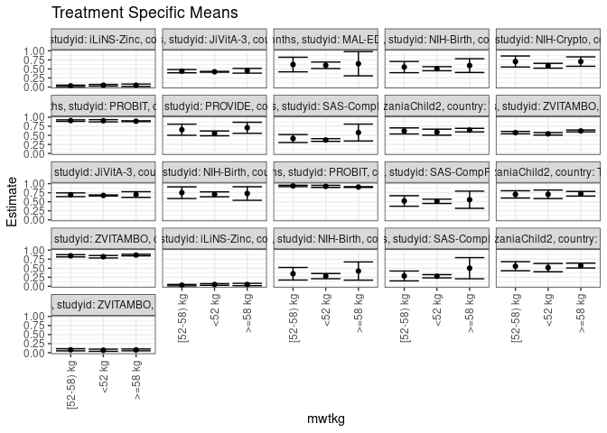

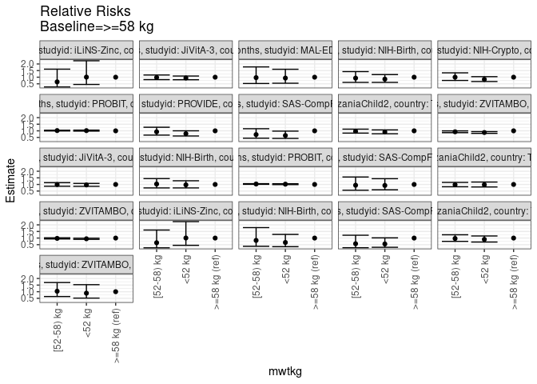

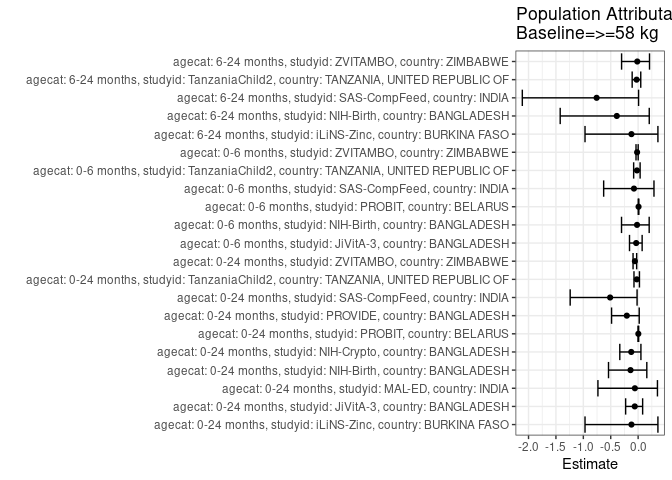

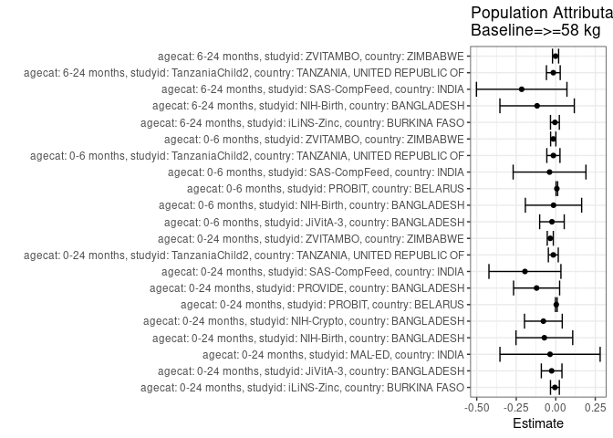

## Results Table

### Parameter: TSM

| agecat | studyid | country | intervention_level | baseline_level | estimate | ci_lower | ci_upper |
| --- | --- | --- | --- | --- | --- | --- | --- |
| 0-24 months | iLiNS-Zinc | BURKINA FASO | >=58 kg | NA | 0.0494505 | 0.0167815 | 0.0821196 |
| 0-24 months | iLiNS-Zinc | BURKINA FASO | <52 kg | NA | 0.0497238 | 0.0270395 | 0.0724080 |
| 0-24 months | iLiNS-Zinc | BURKINA FASO | [52-58) kg | NA | 0.0320000 | 0.0119568 | 0.0520432 |
| 0-24 months | JiVitA-3 | BANGLADESH | >=58 kg | NA | 0.4484162 | 0.3824218 | 0.5144105 |
| 0-24 months | JiVitA-3 | BANGLADESH | <52 kg | NA | 0.4206547 | 0.4090272 | 0.4322822 |
| 0-24 months | JiVitA-3 | BANGLADESH | [52-58) kg | NA | 0.4373579 | 0.3928730 | 0.4818429 |
| 0-24 months | MAL-ED | INDIA | >=58 kg | NA | 0.6428571 | 0.3090040 | 0.9767102 |
| 0-24 months | MAL-ED | INDIA | <52 kg | NA | 0.6000000 | 0.5104195 | 0.6895805 |
| 0-24 months | MAL-ED | INDIA | [52-58) kg | NA | 0.6206897 | 0.4196644 | 0.8217149 |
| 0-24 months | NIH-Birth | BANGLADESH | >=58 kg | NA | 0.5923516 | 0.4018994 | 0.7828038 |
| 0-24 months | NIH-Birth | BANGLADESH | <52 kg | NA | 0.5057256 | 0.4492213 | 0.5622299 |
| 0-24 months | NIH-Birth | BANGLADESH | [52-58) kg | NA | 0.5506509 | 0.3960412 | 0.7052607 |
| 0-24 months | NIH-Crypto | BANGLADESH | >=58 kg | NA | 0.7029821 | 0.5729086 | 0.8330556 |
| 0-24 months | NIH-Crypto | BANGLADESH | <52 kg | NA | 0.5877404 | 0.5214659 | 0.6540148 |
| 0-24 months | NIH-Crypto | BANGLADESH | [52-58) kg | NA | 0.7041489 | 0.5517685 | 0.8565294 |
| 0-24 months | PROBIT | BELARUS | >=58 kg | NA | 0.8894726 | 0.8780780 | 0.9008672 |
| 0-24 months | PROBIT | BELARUS | <52 kg | NA | 0.9024395 | 0.8718362 | 0.9330429 |
| 0-24 months | PROBIT | BELARUS | [52-58) kg | NA | 0.9058951 | 0.8844887 | 0.9273015 |
| 0-24 months | PROVIDE | BANGLADESH | >=58 kg | NA | 0.7087007 | 0.5565476 | 0.8608538 |
| 0-24 months | PROVIDE | BANGLADESH | <52 kg | NA | 0.5538834 | 0.4874697 | 0.6202971 |
| 0-24 months | PROVIDE | BANGLADESH | [52-58) kg | NA | 0.6550233 | 0.5016798 | 0.8083668 |
| 0-24 months | SAS-CompFeed | INDIA | >=58 kg | NA | 0.5764716 | 0.3433015 | 0.8096417 |
| 0-24 months | SAS-CompFeed | INDIA | <52 kg | NA | 0.3713901 | 0.3342281 | 0.4085521 |
| 0-24 months | SAS-CompFeed | INDIA | [52-58) kg | NA | 0.4119710 | 0.3027095 | 0.5212325 |
| 0-24 months | TanzaniaChild2 | TANZANIA, UNITED REPUBLIC OF | >=58 kg | NA | 0.6438592 | 0.5947999 | 0.6929185 |
| 0-24 months | TanzaniaChild2 | TANZANIA, UNITED REPUBLIC OF | <52 kg | NA | 0.5869208 | 0.5040077 | 0.6698339 |
| 0-24 months | TanzaniaChild2 | TANZANIA, UNITED REPUBLIC OF | [52-58) kg | NA | 0.6214027 | 0.5378503 | 0.7049551 |
| 0-24 months | ZVITAMBO | ZIMBABWE | >=58 kg | NA | 0.6205923 | 0.5944074 | 0.6467771 |
| 0-24 months | ZVITAMBO | ZIMBABWE | <52 kg | NA | 0.5413053 | 0.5073163 | 0.5752943 |
| 0-24 months | ZVITAMBO | ZIMBABWE | [52-58) kg | NA | 0.5746726 | 0.5412134 | 0.6081318 |
| 0-6 months | JiVitA-3 | BANGLADESH | >=58 kg | NA | 0.6995387 | 0.6210252 | 0.7780521 |
| 0-6 months | JiVitA-3 | BANGLADESH | <52 kg | NA | 0.6734671 | 0.6594666 | 0.6874675 |
| 0-6 months | JiVitA-3 | BANGLADESH | [52-58) kg | NA | 0.6933838 | 0.6421084 | 0.7446592 |
| 0-6 months | NIH-Birth | BANGLADESH | >=58 kg | NA | 0.7272727 | 0.5399105 | 0.9146349 |
| 0-6 months | NIH-Birth | BANGLADESH | <52 kg | NA | 0.7052023 | 0.6373168 | 0.7730878 |
| 0-6 months | NIH-Birth | BANGLADESH | [52-58) kg | NA | 0.7500000 | 0.5885262 | 0.9114738 |
| 0-6 months | PROBIT | BELARUS | >=58 kg | NA | 0.9063081 | 0.8954378 | 0.9171783 |
| 0-6 months | PROBIT | BELARUS | <52 kg | NA | 0.9249074 | 0.8961770 | 0.9536379 |
| 0-6 months | PROBIT | BELARUS | [52-58) kg | NA | 0.9365729 | 0.9175281 | 0.9556178 |
| 0-6 months | SAS-CompFeed | INDIA | >=58 kg | NA | 0.5555556 | 0.3186642 | 0.7924469 |
| 0-6 months | SAS-CompFeed | INDIA | <52 kg | NA | 0.5127273 | 0.4532019 | 0.5722526 |
| 0-6 months | SAS-CompFeed | INDIA | [52-58) kg | NA | 0.5217391 | 0.3760549 | 0.6674233 |
| 0-6 months | TanzaniaChild2 | TANZANIA, UNITED REPUBLIC OF | >=58 kg | NA | 0.7211588 | 0.6571778 | 0.7851398 |
| 0-6 months | TanzaniaChild2 | TANZANIA, UNITED REPUBLIC OF | <52 kg | NA | 0.7053304 | 0.5876273 | 0.8230335 |
| 0-6 months | TanzaniaChild2 | TANZANIA, UNITED REPUBLIC OF | [52-58) kg | NA | 0.7029921 | 0.6025722 | 0.8034120 |
| 0-6 months | ZVITAMBO | ZIMBABWE | >=58 kg | NA | 0.8616374 | 0.8396310 | 0.8836439 |
| 0-6 months | ZVITAMBO | ZIMBABWE | <52 kg | NA | 0.8158080 | 0.7820356 | 0.8495805 |
| 0-6 months | ZVITAMBO | ZIMBABWE | [52-58) kg | NA | 0.8415651 | 0.8107948 | 0.8723354 |
| 6-24 months | iLiNS-Zinc | BURKINA FASO | >=58 kg | NA | 0.0494505 | 0.0167815 | 0.0821196 |
| 6-24 months | iLiNS-Zinc | BURKINA FASO | <52 kg | NA | 0.0497238 | 0.0270395 | 0.0724080 |
| 6-24 months | iLiNS-Zinc | BURKINA FASO | [52-58) kg | NA | 0.0320000 | 0.0119568 | 0.0520432 |
| 6-24 months | NIH-Birth | BANGLADESH | >=58 kg | NA | 0.4210526 | 0.1702652 | 0.6718400 |
| 6-24 months | NIH-Birth | BANGLADESH | <52 kg | NA | 0.2810458 | 0.2089924 | 0.3530991 |
| 6-24 months | NIH-Birth | BANGLADESH | [52-58) kg | NA | 0.3461538 | 0.1723455 | 0.5199622 |
| 6-24 months | SAS-CompFeed | INDIA | >=58 kg | NA | 0.5000000 | 0.2080230 | 0.7919770 |
| 6-24 months | SAS-CompFeed | INDIA | <52 kg | NA | 0.2769608 | 0.2328732 | 0.3210483 |
| 6-24 months | SAS-CompFeed | INDIA | [52-58) kg | NA | 0.2857143 | 0.1492017 | 0.4222269 |
| 6-24 months | TanzaniaChild2 | TANZANIA, UNITED REPUBLIC OF | >=58 kg | NA | 0.5724519 | 0.5047967 | 0.6401070 |
| 6-24 months | TanzaniaChild2 | TANZANIA, UNITED REPUBLIC OF | <52 kg | NA | 0.5153277 | 0.4009111 | 0.6297444 |
| 6-24 months | TanzaniaChild2 | TANZANIA, UNITED REPUBLIC OF | [52-58) kg | NA | 0.5543202 | 0.4291300 | 0.6795105 |
| 6-24 months | ZVITAMBO | ZIMBABWE | >=58 kg | NA | 0.0779721 | 0.0519060 | 0.1040381 |
| 6-24 months | ZVITAMBO | ZIMBABWE | <52 kg | NA | 0.0691086 | 0.0392732 | 0.0989441 |
| 6-24 months | ZVITAMBO | ZIMBABWE | [52-58) kg | NA | 0.0807467 | 0.0516430 | 0.1098503 |

### Parameter: E(Y)

| agecat | studyid | country | intervention_level | baseline_level | estimate | ci_lower | ci_upper |
| --- | --- | --- | --- | --- | --- | --- | --- |
| 0-24 months | iLiNS-Zinc | BURKINA FASO | NA | NA | 0.0440806 | 0.0298222 | 0.0583390 |
| 0-24 months | JiVitA-3 | BANGLADESH | NA | NA | 0.4223750 | 0.4112477 | 0.4335024 |
| 0-24 months | MAL-ED | INDIA | NA | NA | 0.6067416 | 0.5268346 | 0.6866486 |
| 0-24 months | NIH-Birth | BANGLADESH | NA | NA | 0.5201900 | 0.4695846 | 0.5707955 |
| 0-24 months | NIH-Crypto | BANGLADESH | NA | NA | 0.6245955 | 0.5705077 | 0.6786833 |
| 0-24 months | PROBIT | BELARUS | NA | NA | 0.8927126 | 0.8831771 | 0.9022480 |
| 0-24 months | PROVIDE | BANGLADESH | NA | NA | 0.5874587 | 0.5306185 | 0.6442990 |
| 0-24 months | SAS-CompFeed | INDIA | NA | NA | 0.3814815 | 0.3463355 | 0.4166275 |
| 0-24 months | TanzaniaChild2 | TANZANIA, UNITED REPUBLIC OF | NA | NA | 0.6283688 | 0.5905321 | 0.6662055 |
| 0-24 months | ZVITAMBO | ZIMBABWE | NA | NA | 0.5858785 | 0.5683064 | 0.6034506 |
| 0-6 months | JiVitA-3 | BANGLADESH | NA | NA | 0.6754071 | 0.6620619 | 0.6887522 |
| 0-6 months | NIH-Birth | BANGLADESH | NA | NA | 0.7130045 | 0.6535890 | 0.7724200 |
| 0-6 months | PROBIT | BELARUS | NA | NA | 0.9132253 | 0.9042495 | 0.9222011 |
| 0-6 months | SAS-CompFeed | INDIA | NA | NA | 0.5162242 | 0.4625356 | 0.5699128 |
| 0-6 months | TanzaniaChild2 | TANZANIA, UNITED REPUBLIC OF | NA | NA | 0.7062315 | 0.6568751 | 0.7555878 |
| 0-6 months | ZVITAMBO | ZIMBABWE | NA | NA | 0.8457341 | 0.8300360 | 0.8614323 |
| 6-24 months | iLiNS-Zinc | BURKINA FASO | NA | NA | 0.0440806 | 0.0298222 | 0.0583390 |
| 6-24 months | NIH-Birth | BANGLADESH | NA | NA | 0.3030303 | 0.2377927 | 0.3682679 |
| 6-24 months | SAS-CompFeed | INDIA | NA | NA | 0.2845011 | 0.2426711 | 0.3263311 |
| 6-24 months | TanzaniaChild2 | TANZANIA, UNITED REPUBLIC OF | NA | NA | 0.5570652 | 0.5044805 | 0.6096499 |
| 6-24 months | ZVITAMBO | ZIMBABWE | NA | NA | 0.0767736 | 0.0605511 | 0.0929961 |

### Parameter: RR

| agecat | studyid | country | intervention_level | baseline_level | estimate | ci_lower | ci_upper |
| --- | --- | --- | --- | --- | --- | --- | --- |
| 0-24 months | iLiNS-Zinc | BURKINA FASO | >=58 kg | >=58 kg | 1.0000000 | 1.0000000 | 1.0000000 |
| 0-24 months | iLiNS-Zinc | BURKINA FASO | <52 kg | >=58 kg | 1.0055249 | 0.4505247 | 2.2442281 |
| 0-24 months | iLiNS-Zinc | BURKINA FASO | [52-58) kg | >=58 kg | 0.6471111 | 0.2603826 | 1.6082211 |
| 0-24 months | JiVitA-3 | BANGLADESH | >=58 kg | >=58 kg | 1.0000000 | 1.0000000 | 1.0000000 |
| 0-24 months | JiVitA-3 | BANGLADESH | <52 kg | >=58 kg | 0.9380899 | 0.8076723 | 1.0895666 |
| 0-24 months | JiVitA-3 | BANGLADESH | [52-58) kg | >=58 kg | 0.9753394 | 0.8156113 | 1.1663484 |
| 0-24 months | MAL-ED | INDIA | >=58 kg | >=58 kg | 1.0000000 | 1.0000000 | 1.0000000 |
| 0-24 months | MAL-ED | INDIA | <52 kg | >=58 kg | 0.9333333 | 0.5436369 | 1.6023766 |
| 0-24 months | MAL-ED | INDIA | [52-58) kg | >=58 kg | 0.9655172 | 0.5237016 | 1.7800664 |
| 0-24 months | NIH-Birth | BANGLADESH | >=58 kg | >=58 kg | 1.0000000 | 1.0000000 | 1.0000000 |
| 0-24 months | NIH-Birth | BANGLADESH | <52 kg | >=58 kg | 0.8537591 | 0.6074391 | 1.1999634 |
| 0-24 months | NIH-Birth | BANGLADESH | [52-58) kg | >=58 kg | 0.9296015 | 0.6065616 | 1.4246844 |
| 0-24 months | NIH-Crypto | BANGLADESH | >=58 kg | >=58 kg | 1.0000000 | 1.0000000 | 1.0000000 |
| 0-24 months | NIH-Crypto | BANGLADESH | <52 kg | >=58 kg | 0.8360673 | 0.6727991 | 1.0389557 |
| 0-24 months | NIH-Crypto | BANGLADESH | [52-58) kg | >=58 kg | 1.0016598 | 0.7533921 | 1.3317399 |
| 0-24 months | PROBIT | BELARUS | >=58 kg | >=58 kg | 1.0000000 | 1.0000000 | 1.0000000 |
| 0-24 months | PROBIT | BELARUS | <52 kg | >=58 kg | 1.0145782 | 0.9784522 | 1.0520381 |
| 0-24 months | PROBIT | BELARUS | [52-58) kg | >=58 kg | 1.0184632 | 0.9914488 | 1.0462136 |
| 0-24 months | PROVIDE | BANGLADESH | >=58 kg | >=58 kg | 1.0000000 | 1.0000000 | 1.0000000 |
| 0-24 months | PROVIDE | BANGLADESH | <52 kg | >=58 kg | 0.7815477 | 0.6096127 | 1.0019753 |
| 0-24 months | PROVIDE | BANGLADESH | [52-58) kg | >=58 kg | 0.9242594 | 0.6729706 | 1.2693801 |
| 0-24 months | SAS-CompFeed | INDIA | >=58 kg | >=58 kg | 1.0000000 | 1.0000000 | 1.0000000 |
| 0-24 months | SAS-CompFeed | INDIA | <52 kg | >=58 kg | 0.6442471 | 0.4245214 | 0.9776992 |
| 0-24 months | SAS-CompFeed | INDIA | [52-58) kg | >=58 kg | 0.7146423 | 0.4409796 | 1.1581344 |
| 0-24 months | TanzaniaChild2 | TANZANIA, UNITED REPUBLIC OF | >=58 kg | >=58 kg | 1.0000000 | 1.0000000 | 1.0000000 |
| 0-24 months | TanzaniaChild2 | TANZANIA, UNITED REPUBLIC OF | <52 kg | >=58 kg | 0.9115670 | 0.7763988 | 1.0702674 |
| 0-24 months | TanzaniaChild2 | TANZANIA, UNITED REPUBLIC OF | [52-58) kg | >=58 kg | 0.9651220 | 0.8270386 | 1.1262599 |
| 0-24 months | ZVITAMBO | ZIMBABWE | >=58 kg | >=58 kg | 1.0000000 | 1.0000000 | 1.0000000 |
| 0-24 months | ZVITAMBO | ZIMBABWE | <52 kg | >=58 kg | 0.8722399 | 0.8087694 | 0.9406914 |
| 0-24 months | ZVITAMBO | ZIMBABWE | [52-58) kg | >=58 kg | 0.9260067 | 0.8618157 | 0.9949790 |
| 0-6 months | JiVitA-3 | BANGLADESH | >=58 kg | >=58 kg | 1.0000000 | 1.0000000 | 1.0000000 |
| 0-6 months | JiVitA-3 | BANGLADESH | <52 kg | >=58 kg | 0.9627303 | 0.8589084 | 1.0791019 |
| 0-6 months | JiVitA-3 | BANGLADESH | [52-58) kg | >=58 kg | 0.9912016 | 0.8665539 | 1.1337789 |
| 0-6 months | NIH-Birth | BANGLADESH | >=58 kg | >=58 kg | 1.0000000 | 1.0000000 | 1.0000000 |
| 0-6 months | NIH-Birth | BANGLADESH | <52 kg | >=58 kg | 0.9696532 | 0.7365063 | 1.2766045 |
| 0-6 months | NIH-Birth | BANGLADESH | [52-58) kg | >=58 kg | 1.0312500 | 0.7371449 | 1.4426967 |
| 0-6 months | PROBIT | BELARUS | >=58 kg | >=58 kg | 1.0000000 | 1.0000000 | 1.0000000 |
| 0-6 months | PROBIT | BELARUS | <52 kg | >=58 kg | 1.0205222 | 0.9870944 | 1.0550820 |
| 0-6 months | PROBIT | BELARUS | [52-58) kg | >=58 kg | 1.0333936 | 1.0092790 | 1.0580843 |
| 0-6 months | SAS-CompFeed | INDIA | >=58 kg | >=58 kg | 1.0000000 | 1.0000000 | 1.0000000 |
| 0-6 months | SAS-CompFeed | INDIA | <52 kg | >=58 kg | 0.9229091 | 0.5932432 | 1.4357707 |
| 0-6 months | SAS-CompFeed | INDIA | [52-58) kg | >=58 kg | 0.9391304 | 0.5641157 | 1.5634487 |
| 0-6 months | TanzaniaChild2 | TANZANIA, UNITED REPUBLIC OF | >=58 kg | >=58 kg | 1.0000000 | 1.0000000 | 1.0000000 |
| 0-6 months | TanzaniaChild2 | TANZANIA, UNITED REPUBLIC OF | <52 kg | >=58 kg | 0.9780514 | 0.8098536 | 1.1811820 |
| 0-6 months | TanzaniaChild2 | TANZANIA, UNITED REPUBLIC OF | [52-58) kg | >=58 kg | 0.9748090 | 0.8247762 | 1.1521339 |
| 0-6 months | ZVITAMBO | ZIMBABWE | >=58 kg | >=58 kg | 1.0000000 | 1.0000000 | 1.0000000 |
| 0-6 months | ZVITAMBO | ZIMBABWE | <52 kg | >=58 kg | 0.9468113 | 0.9018695 | 0.9939926 |
| 0-6 months | ZVITAMBO | ZIMBABWE | [52-58) kg | >=58 kg | 0.9767044 | 0.9340772 | 1.0212771 |
| 6-24 months | iLiNS-Zinc | BURKINA FASO | >=58 kg | >=58 kg | 1.0000000 | 1.0000000 | 1.0000000 |
| 6-24 months | iLiNS-Zinc | BURKINA FASO | <52 kg | >=58 kg | 1.0055249 | 0.4505247 | 2.2442281 |
| 6-24 months | iLiNS-Zinc | BURKINA FASO | [52-58) kg | >=58 kg | 0.6471111 | 0.2603826 | 1.6082211 |
| 6-24 months | NIH-Birth | BANGLADESH | >=58 kg | >=58 kg | 1.0000000 | 1.0000000 | 1.0000000 |
| 6-24 months | NIH-Birth | BANGLADESH | <52 kg | >=58 kg | 0.6674837 | 0.3488386 | 1.2771937 |
| 6-24 months | NIH-Birth | BANGLADESH | [52-58) kg | >=58 kg | 0.8221154 | 0.3772729 | 1.7914718 |
| 6-24 months | SAS-CompFeed | INDIA | >=58 kg | >=58 kg | 1.0000000 | 1.0000000 | 1.0000000 |
| 6-24 months | SAS-CompFeed | INDIA | <52 kg | >=58 kg | 0.5539216 | 0.3024033 | 1.0146354 |
| 6-24 months | SAS-CompFeed | INDIA | [52-58) kg | >=58 kg | 0.5714286 | 0.2687084 | 1.2151857 |
| 6-24 months | TanzaniaChild2 | TANZANIA, UNITED REPUBLIC OF | >=58 kg | >=58 kg | 1.0000000 | 1.0000000 | 1.0000000 |
| 6-24 months | TanzaniaChild2 | TANZANIA, UNITED REPUBLIC OF | <52 kg | >=58 kg | 0.9002115 | 0.6998495 | 1.1579356 |
| 6-24 months | TanzaniaChild2 | TANZANIA, UNITED REPUBLIC OF | [52-58) kg | >=58 kg | 0.9683264 | 0.7502609 | 1.2497732 |
| 6-24 months | ZVITAMBO | ZIMBABWE | >=58 kg | >=58 kg | 1.0000000 | 1.0000000 | 1.0000000 |
| 6-24 months | ZVITAMBO | ZIMBABWE | <52 kg | >=58 kg | 0.8863257 | 0.5132305 | 1.5306438 |
| 6-24 months | ZVITAMBO | ZIMBABWE | [52-58) kg | >=58 kg | 1.0355845 | 0.6333667 | 1.6932299 |

### Parameter: PAR

| agecat | studyid | country | intervention_level | baseline_level | estimate | ci_lower | ci_upper |
| --- | --- | --- | --- | --- | --- | --- | --- |
| 0-24 months | iLiNS-Zinc | BURKINA FASO | >=58 kg | NA | -0.0053699 | -0.0333220 | 0.0225821 |
| 0-24 months | JiVitA-3 | BANGLADESH | >=58 kg | NA | -0.0260411 | -0.0912864 | 0.0392041 |
| 0-24 months | MAL-ED | INDIA | >=58 kg | NA | -0.0361156 | -0.3530819 | 0.2808508 |
| 0-24 months | NIH-Birth | BANGLADESH | >=58 kg | NA | -0.0721616 | -0.2516093 | 0.1072861 |
| 0-24 months | NIH-Crypto | BANGLADESH | >=58 kg | NA | -0.0783867 | -0.1978323 | 0.0410590 |
| 0-24 months | PROBIT | BELARUS | >=58 kg | NA | 0.0032400 | -0.0023028 | 0.0087827 |
| 0-24 months | PROVIDE | BANGLADESH | >=58 kg | NA | -0.1212420 | -0.2669883 | 0.0245044 |
| 0-24 months | SAS-CompFeed | INDIA | >=58 kg | NA | -0.1949901 | -0.4226568 | 0.0326765 |
| 0-24 months | TanzaniaChild2 | TANZANIA, UNITED REPUBLIC OF | >=58 kg | NA | -0.0154904 | -0.0468344 | 0.0158536 |
| 0-24 months | ZVITAMBO | ZIMBABWE | >=58 kg | NA | -0.0347138 | -0.0539359 | -0.0154916 |
| 0-6 months | JiVitA-3 | BANGLADESH | >=58 kg | NA | -0.0241316 | -0.1017978 | 0.0535346 |
| 0-6 months | NIH-Birth | BANGLADESH | >=58 kg | NA | -0.0142682 | -0.1923365 | 0.1638001 |
| 0-6 months | PROBIT | BELARUS | >=58 kg | NA | 0.0069172 | 0.0018547 | 0.0119797 |
| 0-6 months | SAS-CompFeed | INDIA | >=58 kg | NA | -0.0393314 | -0.2696368 | 0.1909741 |
| 0-6 months | TanzaniaChild2 | TANZANIA, UNITED REPUBLIC OF | >=58 kg | NA | -0.0149274 | -0.0565300 | 0.0266753 |
| 0-6 months | ZVITAMBO | ZIMBABWE | >=58 kg | NA | -0.0159033 | -0.0325323 | 0.0007257 |
| 6-24 months | iLiNS-Zinc | BURKINA FASO | >=58 kg | NA | -0.0053699 | -0.0333220 | 0.0225821 |
| 6-24 months | NIH-Birth | BANGLADESH | >=58 kg | NA | -0.1180223 | -0.3533429 | 0.1172982 |
| 6-24 months | SAS-CompFeed | INDIA | >=58 kg | NA | -0.2154989 | -0.5017372 | 0.0707393 |
| 6-24 months | TanzaniaChild2 | TANZANIA, UNITED REPUBLIC OF | >=58 kg | NA | -0.0153866 | -0.0589317 | 0.0281585 |
| 6-24 months | ZVITAMBO | ZIMBABWE | >=58 kg | NA | -0.0011985 | -0.0205737 | 0.0181767 |

### Parameter: PAF

| agecat | studyid | country | intervention_level | baseline_level | estimate | ci_lower | ci_upper |
| --- | --- | --- | --- | --- | --- | --- | --- |
| 0-24 months | iLiNS-Zinc | BURKINA FASO | >=58 kg | NA | -0.1218210 | -0.9692425 | 0.3609307 |
| 0-24 months | JiVitA-3 | BANGLADESH | >=58 kg | NA | -0.0616540 | -0.2279727 | 0.0821382 |
| 0-24 months | MAL-ED | INDIA | >=58 kg | NA | -0.0595238 | -0.7337052 | 0.3524904 |
| 0-24 months | NIH-Birth | BANGLADESH | >=58 kg | NA | -0.1387216 | -0.5404787 | 0.1582572 |
| 0-24 months | NIH-Crypto | BANGLADESH | >=58 kg | NA | -0.1254999 | -0.3345821 | 0.0508265 |
| 0-24 months | PROBIT | BELARUS | >=58 kg | NA | 0.0036293 | -0.0026021 | 0.0098220 |
| 0-24 months | PROVIDE | BANGLADESH | >=58 kg | NA | -0.2063838 | -0.4847669 | 0.0198045 |
| 0-24 months | SAS-CompFeed | INDIA | >=58 kg | NA | -0.5111391 | -1.2400295 | -0.0194248 |
| 0-24 months | TanzaniaChild2 | TANZANIA, UNITED REPUBLIC OF | >=58 kg | NA | -0.0246518 | -0.0757954 | 0.0240605 |
| 0-24 months | ZVITAMBO | ZIMBABWE | >=58 kg | NA | -0.0592508 | -0.0926029 | -0.0269168 |
| 0-6 months | JiVitA-3 | BANGLADESH | >=58 kg | NA | -0.0357290 | -0.1573669 | 0.0731250 |
| 0-6 months | NIH-Birth | BANGLADESH | >=58 kg | NA | -0.0200114 | -0.3030056 | 0.2015204 |
| 0-6 months | PROBIT | BELARUS | >=58 kg | NA | 0.0075745 | 0.0020051 | 0.0131128 |
| 0-6 months | SAS-CompFeed | INDIA | >=58 kg | NA | -0.0761905 | -0.6290300 | 0.2890334 |
| 0-6 months | TanzaniaChild2 | TANZANIA, UNITED REPUBLIC OF | >=58 kg | NA | -0.0211366 | -0.0818244 | 0.0361467 |
| 0-6 months | ZVITAMBO | ZIMBABWE | >=58 kg | NA | -0.0188042 | -0.0386868 | 0.0006979 |
| 6-24 months | iLiNS-Zinc | BURKINA FASO | >=58 kg | NA | -0.1218210 | -0.9692425 | 0.3609307 |
| 6-24 months | NIH-Birth | BANGLADESH | >=58 kg | NA | -0.3894737 | -1.4221313 | 0.2029181 |
| 6-24 months | SAS-CompFeed | INDIA | >=58 kg | NA | -0.7574627 | -2.1133642 | 0.0079300 |
| 6-24 months | TanzaniaChild2 | TANZANIA, UNITED REPUBLIC OF | >=58 kg | NA | -0.0276209 | -0.1089381 | 0.0477334 |
| 6-24 months | ZVITAMBO | ZIMBABWE | >=58 kg | NA | -0.0156108 | -0.3018531 | 0.2076947 |